# EDA - Variables Económicas y Sociodemográficas

# Exploración de Datos

## Exploración de datos inicial

### Valores ausentes

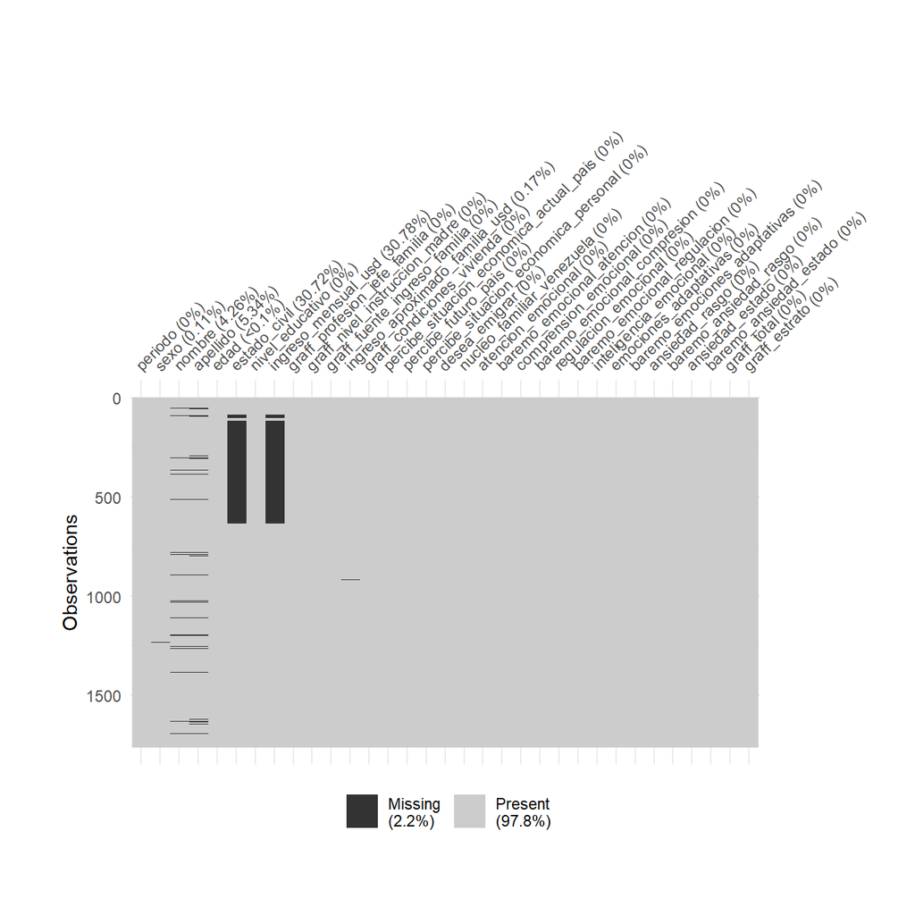

### Outliers

Variables que se ven más afectadas por outliers:

- `ingreso_aproximado_familia_usd`
- `ingreso_mensual_usd`
- `ansiedad_rasgo`
- `emociones_adaptativas`
- `ansiedad_estado`
- `regulacion_emocional`

#### Outliers por variable:

- `ingreso_aproximado_familia_usd`: Es la variable más problemática a nivel de Outliers.
  - Un sujeto ingresó un ingreso familiar de `2.719383e+34`. Se ha eliminado este valor
  - Método de imputación: Eliminar

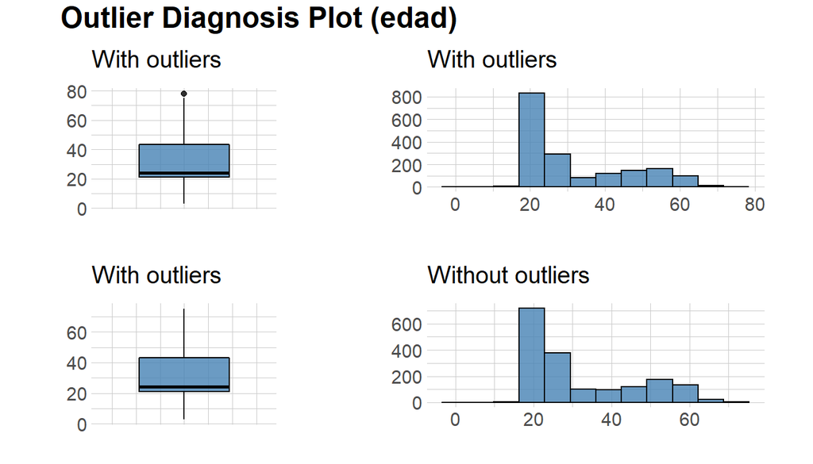

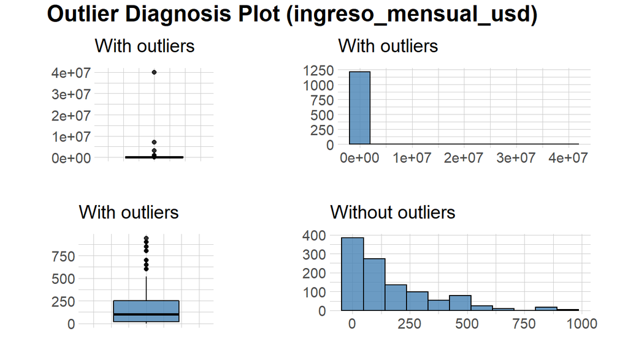

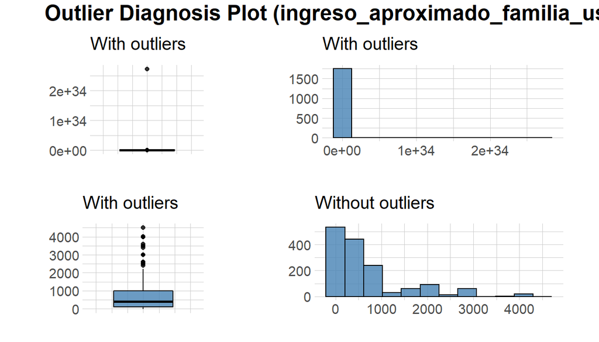

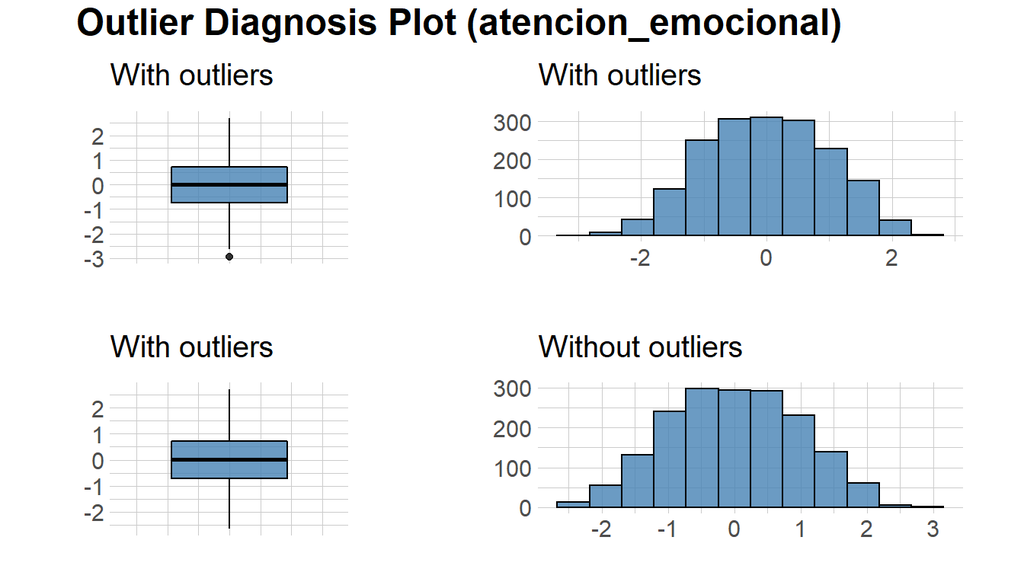

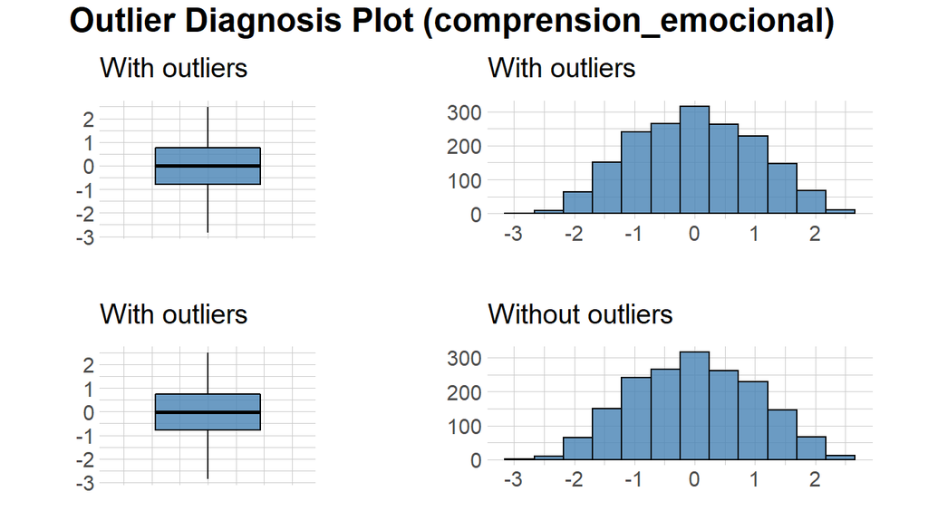

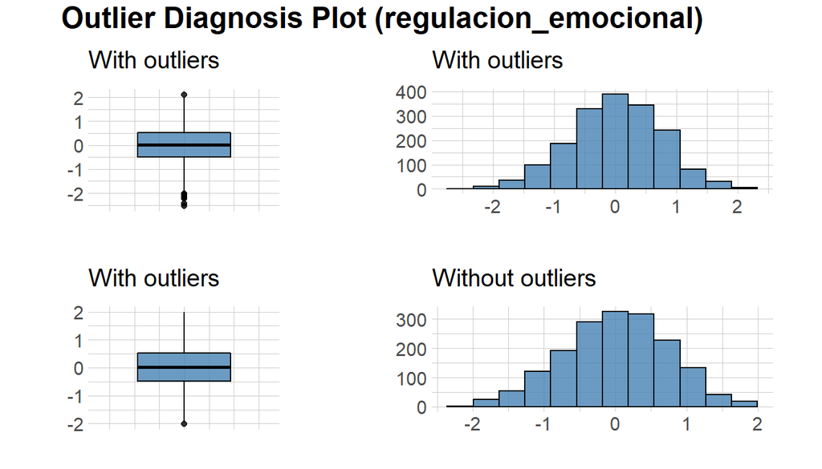

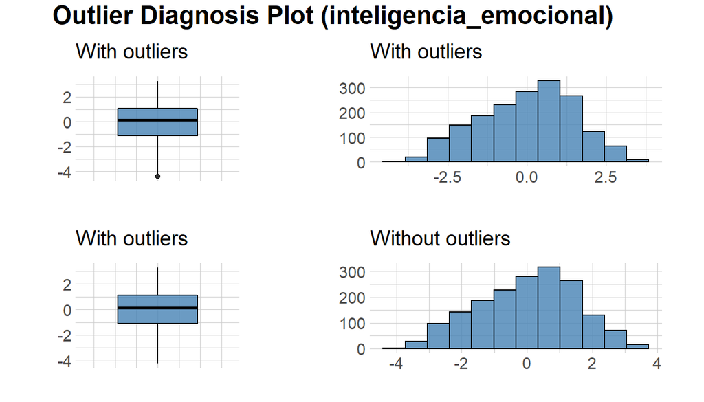

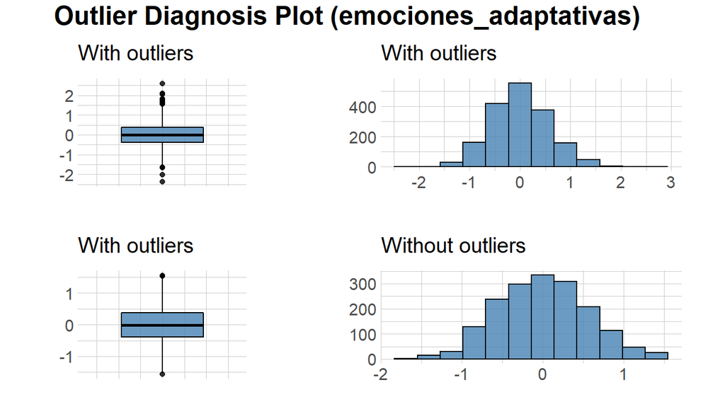

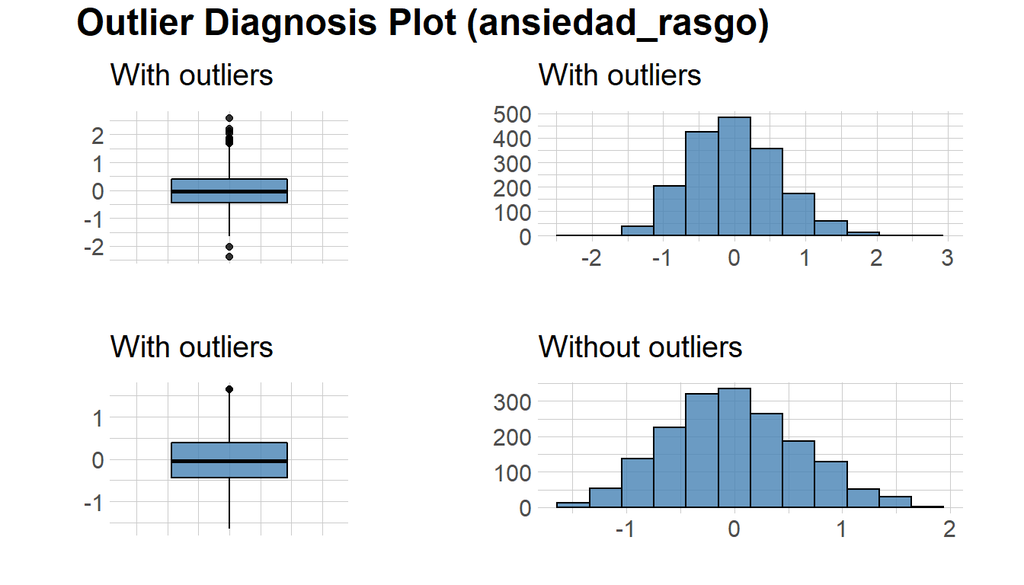

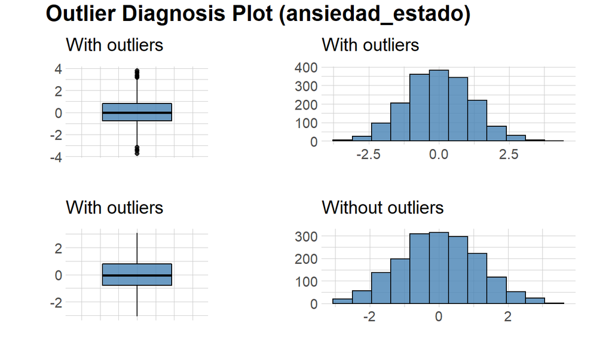

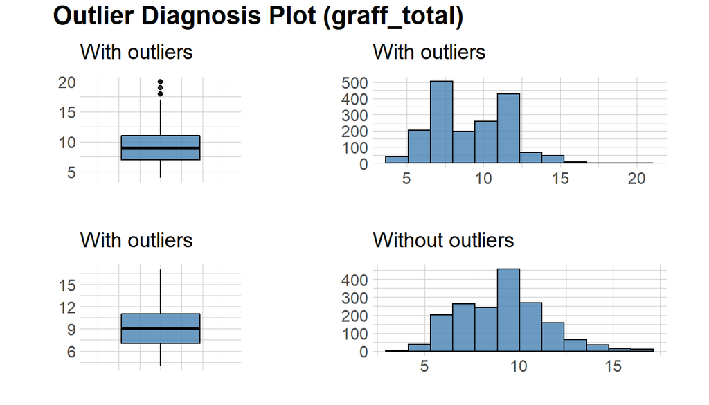

[figure not shown]

[1 more figures not shown]

## Análisis descriptivo univariante

### Ingreso mensual

- Hemos considerado a estos outliers como representativos de la población.

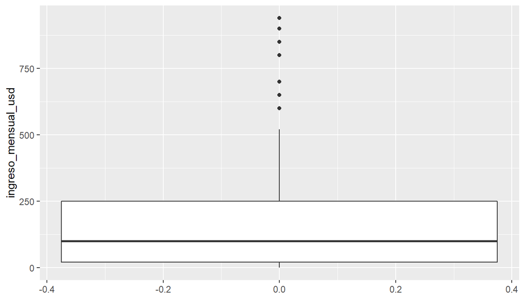

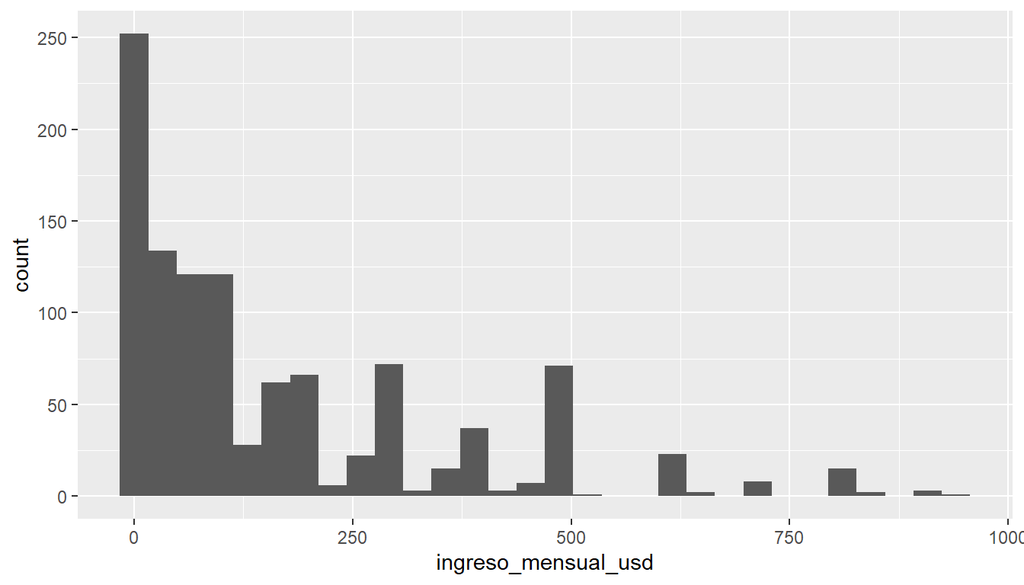

### Ingreso mensual familiar

- Hemos considerado a estos outliers como representativos de la población.

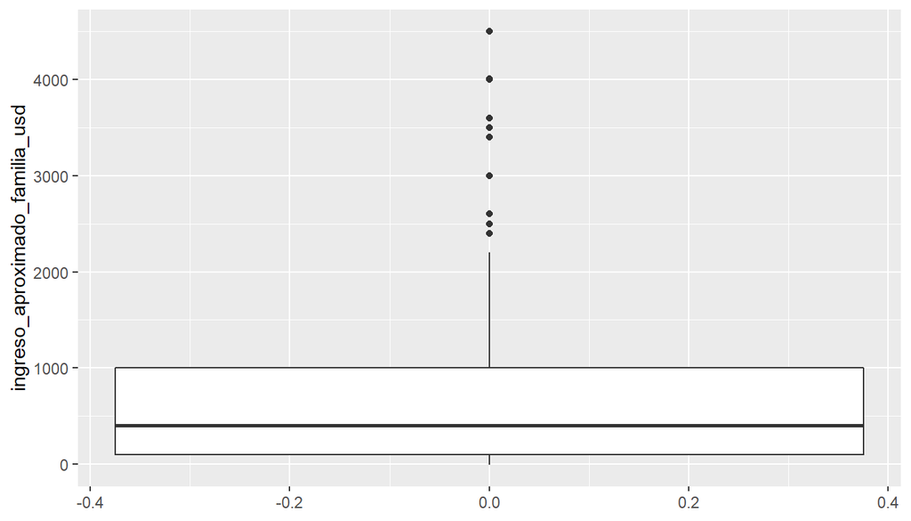

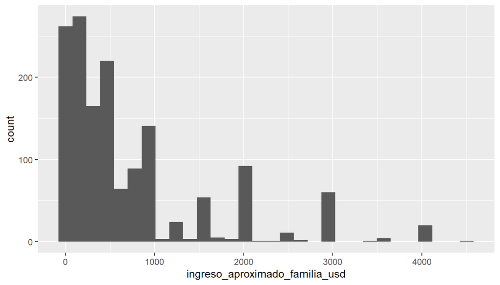

### Percepcion economica pais

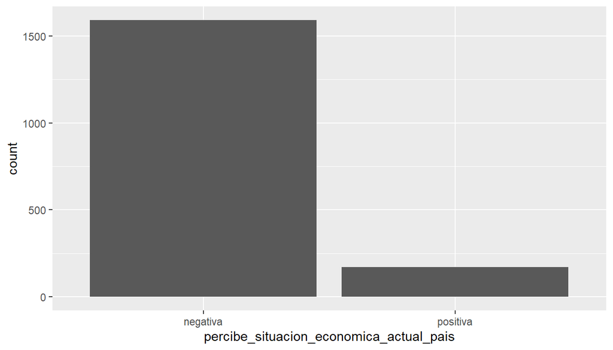

### Percepcion economica personal

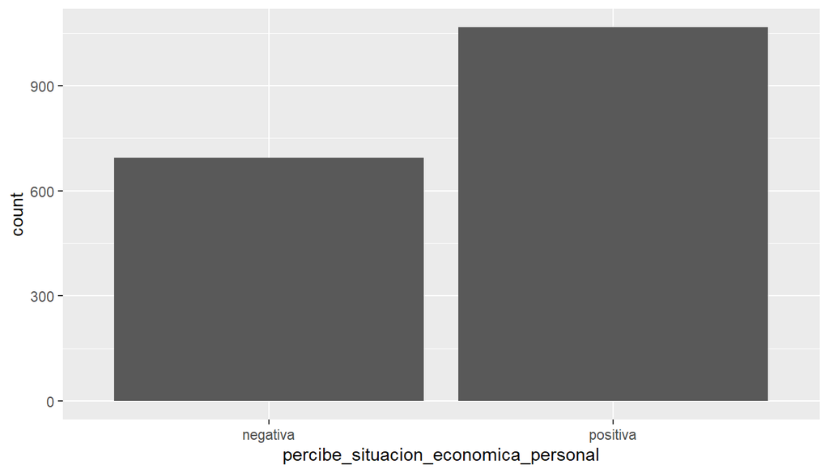

### Escala Graffar

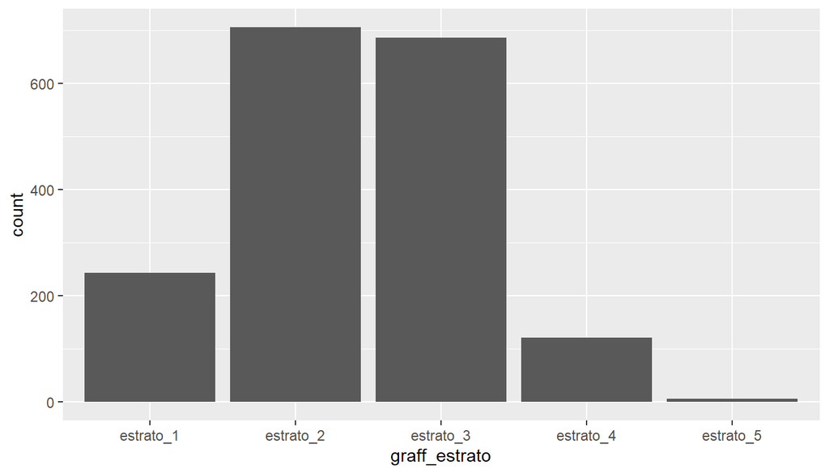

## Descriptivo Bivariado

### Ingreso mensual personal

- No existe una relación estadísticamente significativa entre esta variable y `ansiedad_estado`

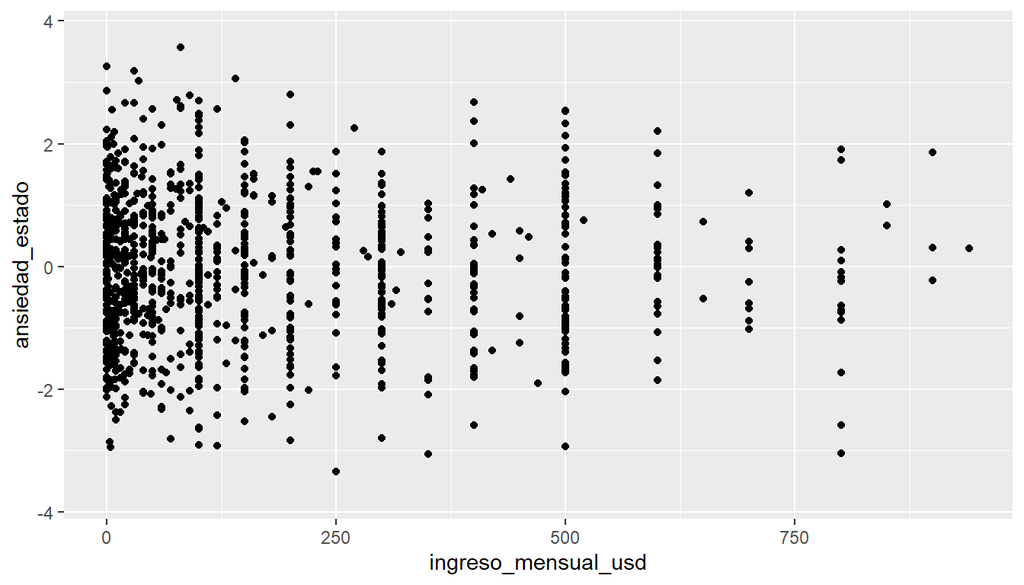

```
##
##  Pearson's product-moment correlation
##
## data:  df_congreso_clean$ingreso_mensual_usd and df_congreso_clean$ansiedad_estado
## t = -0.52924, df = 1073, p-value = 0.5967
## alternative hypothesis: true correlation is not equal to 0
## 95 percent confidence interval:
##  -0.07587186  0.04367810
## sample estimates:
##         cor
## -0.01615462
```

### Ingreso mensual familiar

- No existe una relación estadísticamente significativa entre esta variable y `ansiedad_estado`

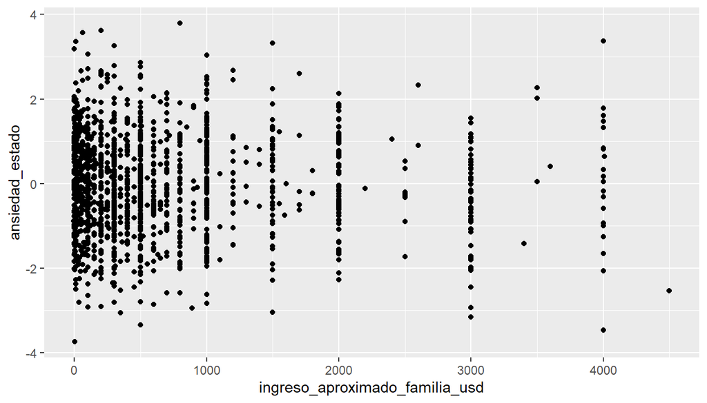

```
##
##  Pearson's product-moment correlation
##
## data:  df_congreso_clean$ingreso_aproximado_familia_usd and df_congreso_clean$ansiedad_estado
## t = -0.11667, df = 1498, p-value = 0.9071
## alternative hypothesis: true correlation is not equal to 0
## 95 percent confidence interval:
##  -0.05361967  0.04760631
## sample estimates:
##          cor
## -0.003014403
```

### Percepcion economica pais

- No existe una relación estadísticamente significativa entre esta variable y `ansiedad_estado`

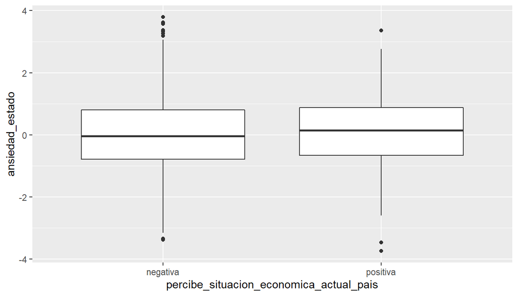

```
##
##  Pearson's Chi-squared test
##
## data:  tbl_siteconpais
## X-squared = 1.4747, df = 2, p-value = 0.4784
```

```
## [1] 0.0289378
```

```
##
##  Welch Two Sample t-test
##
## data:  ansiedad_estado by percibe_situacion_economica_actual_pais
## t = -0.95183, df = 209.41, p-value = 0.3423
## alternative hypothesis: true difference in means is not equal to 0
## 95 percent confidence interval:
##  -0.27131018  0.09462564
## sample estimates:
## mean in group negativa mean in group positiva
##           -0.008578381            0.079763891
```

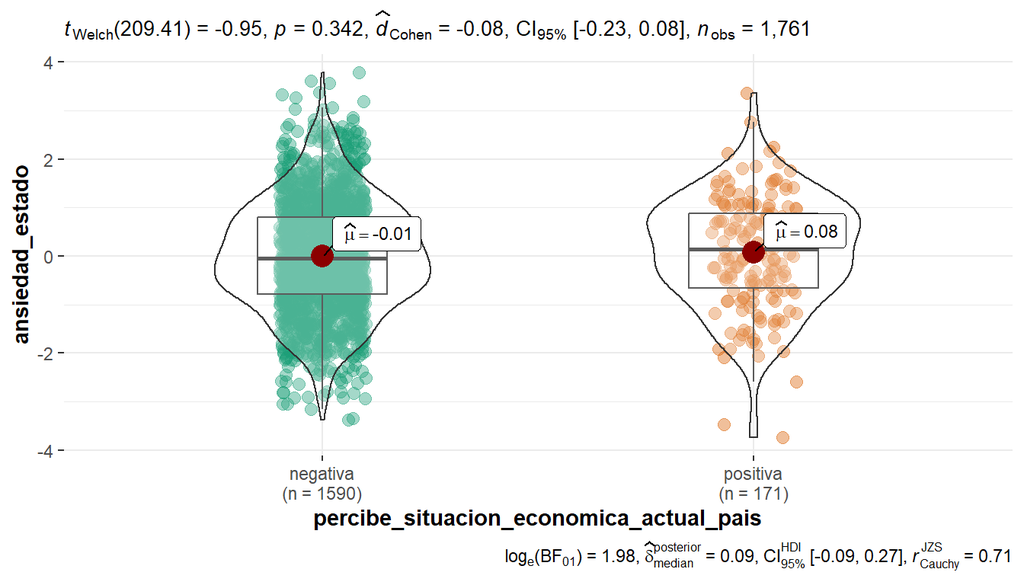

### Percepcion economica personal

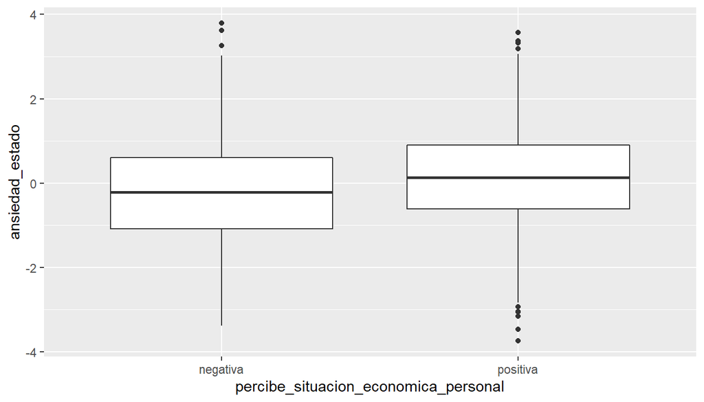

```
##
##  Pearson's Chi-squared test
##
## data:  tbl_stieconpersonal
## X-squared = 45.172, df = 2, p-value = 1.553e-10
```

```
## [1] 0.1601603
```

```
##
##  Welch Two Sample t-test
##
## data:  ansiedad_estado by percibe_situacion_economica_personal
## t = -6.0802, df = 1428.3, p-value = 1.538e-09
## alternative hypothesis: true difference in means is not equal to 0
## 95 percent confidence interval:
##  -0.4575431 -0.2343277
## sample estimates:
## mean in group negativa mean in group positiva
##             -0.2094078              0.1365276
```

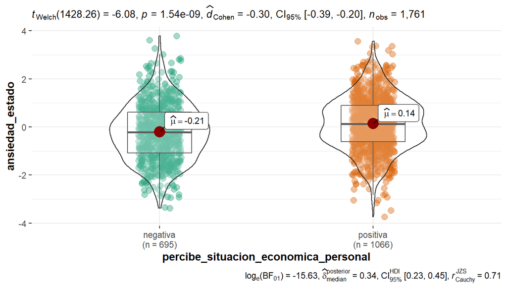

### Escala Graffar

- El nivel socioeconomico según la escala graffar no es dependiente con la ansiedad.

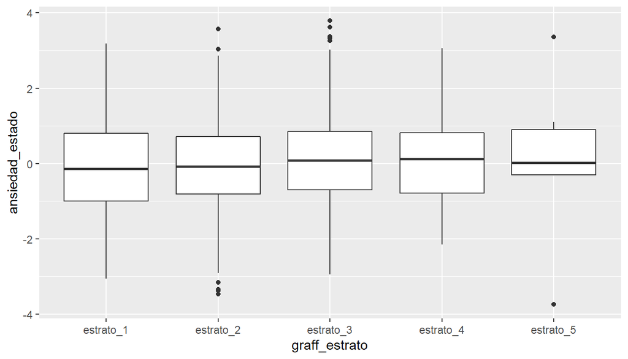

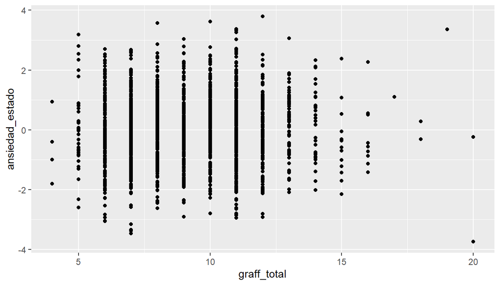

```
##
##  Pearson's Chi-squared test
##
## data:  df_congreso_clean$baremo_ansiedad_estado and df_congreso_clean$graff_estrato
## X-squared = 7.1979, df = 8, p-value = 0.5154
```

```
##
##  Pearson's product-moment correlation
##
## data:  df_congreso_clean$ansiedad_estado and df_congreso_clean$graff_total
## t = 1.3673, df = 1759, p-value = 0.1717
## alternative hypothesis: true correlation is not equal to 0
## 95 percent confidence interval:
##  -0.01414835  0.07917539
## sample estimates:
##        cor
## 0.03258454
```

## Supuestos

### Normalidad de VD - `ansiedad_estado`

- La VD tiene una distribución normal

```
##
##  Shapiro-Wilk normality test
##
## data:  df_congreso_clean$ansiedad_estado
## W = 0.99914, p-value = 0.6009
```